# THX 2기 퀴즈1 - 답안지

최요한

2023-08-27

## 0. tidyverse, starwars

```r
library(tidyverse)
starwars
```

```
## # A tibble: 87 × 14
##    name     height  mass hair_color skin_color eye_color birth_year sex   gender
##    <chr>     <int> <dbl> <chr>      <chr>      <chr>          <dbl> <chr> <chr>
##  1 Luke Sk…    172    77 blond      fair       blue            19   male  mascu…
##  2 C-3PO       167    75 <NA>       gold       yellow         112   none  mascu…
##  3 R2-D2        96    32 <NA>       white, bl… red             33   none  mascu…
##  4 Darth V…    202   136 none       white      yellow          41.9 male  mascu…
##  5 Leia Or…    150    49 brown      light      brown           19   fema… femin…
##  6 Owen La…    178   120 brown, gr… light      blue            52   male  mascu…
##  7 Beru Wh…    165    75 brown      light      blue            47   fema… femin…
##  8 R5-D4        97    32 <NA>       white, red red             NA   none  mascu…
##  9 Biggs D…    183    84 black      light      brown           24   male  mascu…
## 10 Obi-Wan…    182    77 auburn, w… fair       blue-gray       57   male  mascu…
## # ℹ 77 more rows
## # ℹ 5 more variables: homeworld <chr>, species <chr>, films <list>,
## #   vehicles <list>, starships <list>
```

## 1. 데이터셋 사이즈 starwars 구조를 확인하시오

> glimpse()  
> str()

```r
starwars
```

```
## # A tibble: 87 × 14
##    name     height  mass hair_color skin_color eye_color birth_year sex   gender
##    <chr>     <int> <dbl> <chr>      <chr>      <chr>          <dbl> <chr> <chr>
##  1 Luke Sk…    172    77 blond      fair       blue            19   male  mascu…
##  2 C-3PO       167    75 <NA>       gold       yellow         112   none  mascu…
##  3 R2-D2        96    32 <NA>       white, bl… red             33   none  mascu…
##  4 Darth V…    202   136 none       white      yellow          41.9 male  mascu…
##  5 Leia Or…    150    49 brown      light      brown           19   fema… femin…
##  6 Owen La…    178   120 brown, gr… light      blue            52   male  mascu…
##  7 Beru Wh…    165    75 brown      light      blue            47   fema… femin…
##  8 R5-D4        97    32 <NA>       white, red red             NA   none  mascu…
##  9 Biggs D…    183    84 black      light      brown           24   male  mascu…
## 10 Obi-Wan…    182    77 auburn, w… fair       blue-gray       57   male  mascu…
## # ℹ 77 more rows
## # ℹ 5 more variables: homeworld <chr>, species <chr>, films <list>,
## #   vehicles <list>, starships <list>
```

### 1-1 starwars 데이터셋은 몇행 몇열인가?

> dim()  
> nrow()  
> ncol()

### 1-2 geom_point(산점도)를 그리시오

> x = gender, y = birth_year  
> nrow()

### 1-3 geom_boxplot()을 그리시오

> x = gender, y = birth_year

### 1-4 species(종족), gender (성별) 조합을 확인하시오

> count()

### 1-5 species(종족), gender (성별), sex(생물학적 성별)을 확인하시오

> count()

### 1-6 (1-4의 결과를 활용해) 히트맵을 그리시오

> geom_tile()  
> scales_fill_gradient()

### 1-7 starwars$gender 에서 NA는 몇개나 있는지 확인하시오

> table(useNA)

```r
starwars |> str()
```

[output not shown]

### 1-8 starwars 에서 NA는 얼마나 있는지 확인하시오 (번외)

```r
colSums(is.na(starwars)) |>
  as.data.frame()
```

```
##            colSums(is.na(starwars))
## name                              0
## height                            6
## mass                             28
## hair_color                        5
## skin_color                        0
## eye_color                         0
## birth_year                       44
## sex                               4
## gender                            4
## homeworld                        10
## species                           4
## films                             0
## vehicles                          0
## starships                         0
```

### 1-9 starwars의 세로줄(컬럼)만 출력하시오

> colnames()

## 2 극장관객수

```r
library(readxl)
library(scales)
library(bbplot)
library(showtext) #번외
showtext_auto()   #번외
```

### 2-1 2019년 극장관객수 xlsx 파일을 불러오시오

> read_excel()  
> 변수명: kobis2019_1excel

[output not shown]

### 2-2 데이터 구조를 파악하시오

> glimpse()  
> str()

### 2-3 세로줄 “개봉일”을 “연도”, “월”, “일”로 나누시오

> mutate()  
> year()  
> month()  
> day()

### 2-4 세로줄 “월”에 값이 없는 것들을 제거하고 몇행으로 줄어드는지 확인하시오 (번외)

> drop_na()

```r
kobis2019_2date |>
  drop_na(월)
```

[output not shown]

### 2-5 2019년 월별 극장 관객수를 구하시오

> drop_na()  
> group_by()  
> summarise()

### 2-6 (2-5 결과를 활용해) 막대 그래프로 그리시오

> geom_bar()

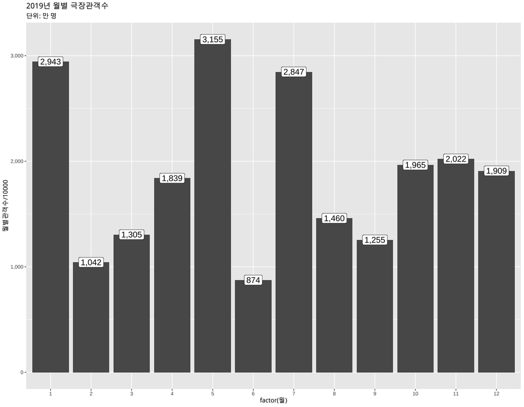

### 2-7 (2-6 결과를 바탕으로) 그래프 심미성을 높이시오 (번외)

> scale_y_continuous(labels = )  
> labs()  
> bbc_style()

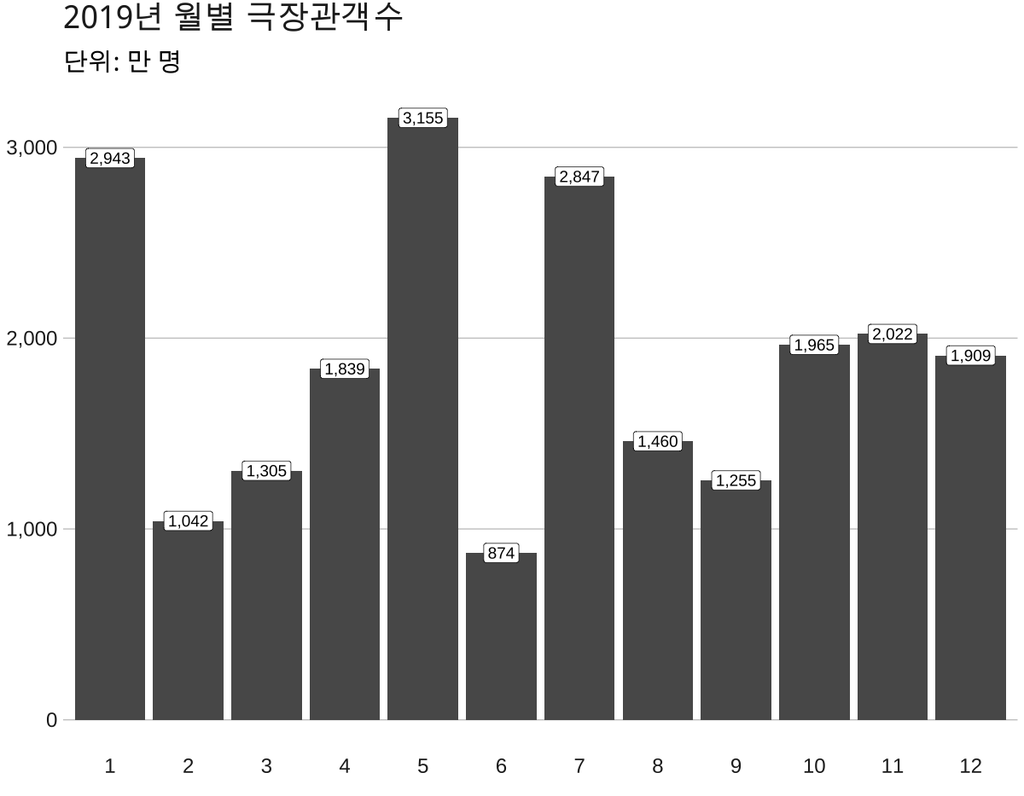

### 2-8 bbc_style을 theme을 활용해 구현하시오 (번외)

> theme()

### 2-9 2019년 관객수 총합은 얼마인지 구하시오

> drop_na(월)  
> summarise()

### 3. 2020년도 극장관객수를 불러오시오

> read_excel()  
> 변수명: kobis2020_1excel

```r
(read_excel("../5st/excel/rawdata/KOBIS_2020.xlsx",
  skip = 4) -> kobis2020_1excel)
```

```
## # A tibble: 4,546 × 18
##     순위 영화명   개봉일               매출액 `매출액\n점유율` 누적매출액 관객수
##    <dbl> <chr>    <dttm>                <dbl>            <dbl>      <dbl>  <dbl>
##  1     1 남산의 … 2020-01-22 00:00:00 4.12e10           0.081     4.12e10 4.75e6
##  2     2 다만 악… 2020-08-05 00:00:00 3.86e10           0.076     3.86e10 4.36e6
##  3     3 반도     2020-07-15 00:00:00 3.31e10           0.065     3.31e10 3.81e6
##  4     4 히트맨   2020-01-22 00:00:00 2.06e10           0.04      2.06e10 2.41e6
##  5     5 테넷     2020-08-26 00:00:00 1.84e10           0.036     1.84e10 1.99e6
##  6     6 백두산   2019-12-19 00:00:00 1.69e10           0.033     6.98e10 1.96e6
##  7     7 #살아있… 2020-06-24 00:00:00 1.60e10           0.031     1.60e10 1.90e6
##  8     8 강철비2… 2020-07-29 00:00:00 1.47e10           0.0290    1.47e10 1.79e6
##  9     9 담보     2020-09-29 00:00:00 1.47e10           0.0290    1.47e10 1.72e6
## 10    10 닥터 두… 2020-01-08 00:00:00 1.34e10           0.026     1.34e10 1.61e6
## # ℹ 4,536 more rows
## # ℹ 11 more variables: 누적관객수 <dbl>, 스크린수 <dbl>, 상영횟수 <dbl>,
## #   대표국적 <chr>, 국적 <chr>, 제작사 <chr>, 배급사 <chr>, 등급 <chr>,
## #   장르 <chr>, 감독 <chr>, 배우 <chr>
```

### 3-1 (2-3부터 2-6까지 코드를 활용해) 2020년도 데이터를 분석하시오

> 변수명: kobis2020_2date

[figure not shown]

```r
kobis2020_1excel |>
  mutate(
    연도 = year(개봉일),
    월 = month(개봉일),
    일 = day(개봉일), .before = 3) -> kobis2020_2date
```

### 3-2 그래프 심미성을 높이시오

> bbc_sytle()

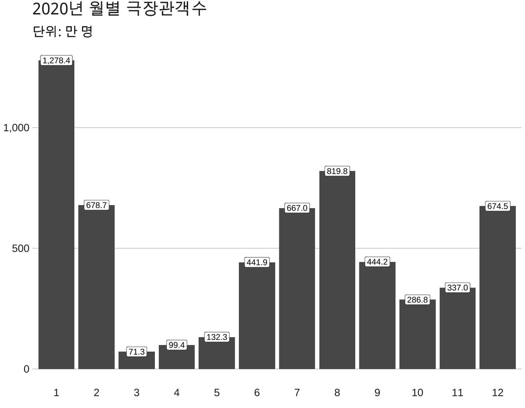

## 4 데이터 합치기

### 4-1 kobis2019_2date 데이터셋에 개봉연도 2019년을 추가하시오

> 변수명: kobis2019_2date -> kobis2019_3year

```r
kobis2019_2date |>
  mutate(개봉연도 = "2019", .before = 3) -> kobis2019_3year
```

### 4-2 kobis2020_2date 데이터셋에 개봉연도 2020년을 추가하시오

> 변수명: kobis2020_2date -> kobis2020_3year

```r
kobis2020_2date |>
  mutate(개봉연도 = "2020", .before = 3) -> kobis2020_3year
```

### 4-3 kobis2020_3year 데이터셋과 kobis2019_3year을 하나로 합치시오

> full_join()

```r
full_join(kobis2019_2date,
  kobis2020_2date)
```

[output not shown]

[output not shown]

### 4-4 2019년과 2020년 극장관객수를 비교하시오

> geom_bar()  
> position = “dodge”

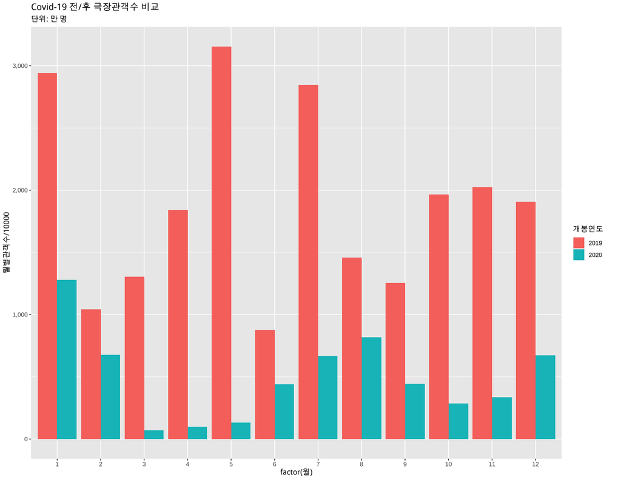

### 4-5 (4-4 그래프의) 심미성을 높이시오

> bbc_sytle()

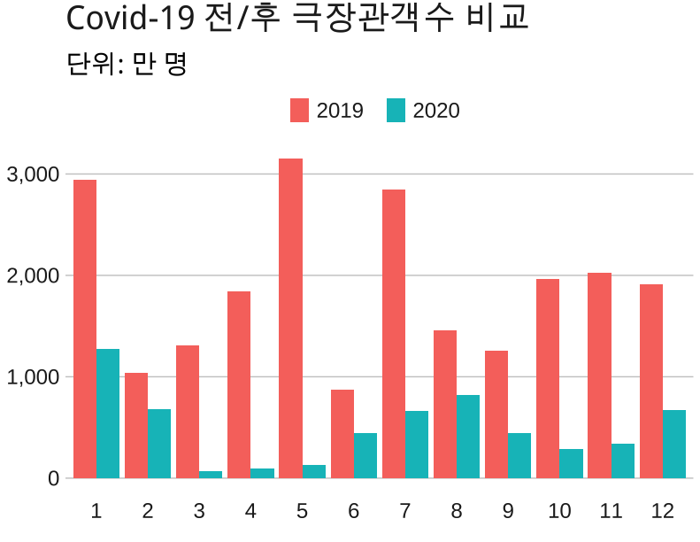

### 4-6 (4-5 그래프의) 심미성을 높이시오

> library(nord)  
> nord

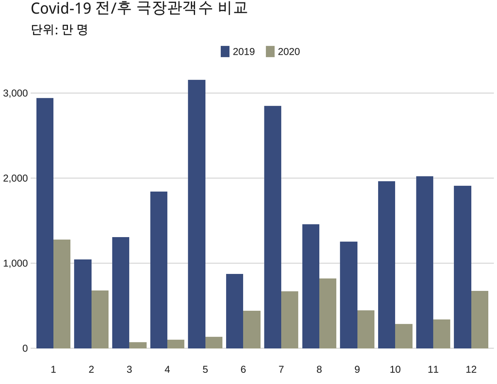

# 퀴즈1 끝